# How to download fundamental data

The Securities and Exchange Commission (SEC) requires US listed companies and securities, including mutual funds to file three quarterly financial statements `(Form 10-Q)` and one annual report `(Form 10-K)`, in addition to various other regulatory filing requirements.

Since the early **1990s**, the SEC made these filings available through its `Electronic Data Gathering, Analysis, and Retrieval (EDGAR)` system. They constitute the primary data source for the fundamental analysis of equity and other securities, such as corporate credit, where the value depends on the business prospects and the financial health of the issuer.

## Automated processing using XBRL markup

Automated analysis of regulatory filings has become easier since the SEC introduced `XBRL`, a free, open, and global standard for the electronic representation and exchange of business reports. `XBRL` is based on `XML`; it relies on [taxonomies](https://www.sec.gov/dera/data/edgar-log-file-data-set.html) that define the meaning of the elements of a report and map to tags that highlight the corresponding information in the electronic version of the report. One such taxonomy represents the US Generally Accepted Accounting Principles (GAAP).

The SEC introduced voluntary XBRL filings in **2005** in response to accounting scandals before requiring this format for all filers since **2009** and continues to expand the mandatory coverage to other regulatory filings. The SEC maintains a website that lists the current taxonomies that shape the content of different filings and can be used to extract specific items.

There are several avenues to track and access fundamental data reported to the SEC:

- As part of the EDGAR Public Dissemination Service (PDS), electronic feeds of accepted filings are available for a fee.
- The SEC updates [RSS feeds](https://www.sec.gov/structureddata/rss-feeds-submitted-filings) every 10 minutes, which list structured disclosure submissions.
- There are public [index files](https://www.sec.gov/edgar/searchedgar/accessing-edgar-data.htm) for the retrieval of all filings through FTP for automated processing.
- The financial statement (and notes) datasets contain parsed XBRL data from all financial statements and the accompanying notes.

# Imports

```python
from io import BytesIO
from zipfile import ZipFile, BadZipFile
import requests
from datetime import date, datetime
from pathlib import Path
import pandas_datareader.data as web
import datetime
import pandas as pd
import json
import re
from pprint import pprint
from bs4 import BeautifulSoup
from collections import Counter
import matplotlib.pyplot as plt
import matplotlib.dates as mdates
import matplotlib.ticker as mticker
```

```python
#plt.style.use('fivethirtyeight')
import seaborn as sns
sns.set(style="darkgrid", color_codes=True)
data_path = Path('data') # perhaps set to external harddrive to accomodate large amount of data
pd.set_option('display.max_columns', None)
```

## Dowload FS & Notes

The following code downloads and extracts all historical filings contained in the [Financial Statement and Notes](https://www.sec.gov/dera/data/financial-statement-and-notes-data-set.html) (FSN) datasets for the given range of quarters:

**Downloads over 40GB of data!**

```python
SEC_URL = 'https://www.sec.gov/files/dera/data/financial-statement-and-notes-data-sets/'

today = pd.Timestamp(date.today())
this_year = today.year
this_quarter = today.quarter

past_years = range(2014, this_year)
filing_periods = [(y, q) for y in past_years for q in range(1, 5)]
filing_periods.extend([(this_year, q) for q in range(1, this_quarter + 1)])
for i, (yr, qtr) in enumerate(filing_periods, 1):
    print(yr, qtr, end=' ', )
    filing = f'{yr}q{qtr}_notes.zip'
    path = data_path / f'{yr}_{qtr}' / 'source'
    if not path.exists():
        path.mkdir(exist_ok=True, parents=True)

    response = requests.get(SEC_URL + filing).content
    try:
        with ZipFile(BytesIO(response)) as zip_file:
            for file in zip_file.namelist():
                local_file = path / file
                if local_file.exists():
                    continue
                with local_file.open('wb') as output:
                    for line in zip_file.open(file).readlines():
                        output.write(line)
    except BadZipFile:
        continue
```

```
2014 1 2014 2 2014 3 2014 4 2015 1 2015 2 2015 3 2015 4 2016 1 2016 2 2016 3 2016 4 2017 1 2017 2 2017 3 2017 4 2018 1 2018 2 2018 3 2018 4 2019 1 2019 2 2019 3 2019 4
```

## Save to parquet

The data is fairly large and to enable faster access than the original text files permit, it is better to convert the text files to binary, columnar parquet format.

```python
for f in data_path.glob('**/*.tsv'):
    file_name = f.stem  + '.parquet'
    path = Path(f.parents[1]) / 'parquet'
    if (path / file_name).exists():
        continue
    if not path.exists():
        path.mkdir(exist_ok=True)
    try:
        df = pd.read_csv(f, sep='\t', encoding='latin1', low_memory=False)
    except:
        print(f)
    df.to_parquet(path / file_name)
```

```
data/2019_2/source/tag.tsv
data/2017_1/source/tag.tsv
data/2014_4/source/txt.tsv
data/2015_2/source/txt.tsv
data/2015_1/source/txt.tsv
data/2015_4/source/txt.tsv
data/2014_3/source/txt.tsv
data/2014_2/source/txt.tsv
data/2014_1/source/txt.tsv
data/2016_1/source/txt.tsv
data/2015_3/source/txt.tsv
```

## Metadata json

```python
file = data_path / '2018_3' / 'source' / '2018q3_notes-metadata.json'
with file.open() as f:
    data = json.load(f)

pprint(data)
```

```
{'@context': 'http://www.w3.org/ns/csvw',
 'dialect': {'delimiter': '\t', 'header': True, 'headerRowCount': 1},
 'tables': [{'tableSchema': {'aboutUrl': 'readme.htm',
                             'columns': [{'datatype': {'base': 'string',
                                                       'maxLength': 20,
                                                       'minLength': 20},
                                          'dc:description': 'Accession Number. '
                                                            'The 20-character '
                                                            'string formed '
                                                            'from the 18-digit '
                                                            'number assigned '
                                                            'by the Commission '
                                                            'to each EDGAR '
                                                            'submission.',
                                          'name': 'adsh',
                                          'required': 'true',
                                          'titles': ['Accession Number']},
                                         {'datatype': {'base': 'decimal',
                                                       'maxLength': 10,
                                                       'minInclusive': 0},
                                          'dc:description': 'Central Index Key '
                                                            '(CIK). Ten digit '
                                                            'number assigned '
                                                            'by the Commission '
                                                            'to each '
                                                            'registrant that '
                                                            'submits filings.',
                                          'name': 'cik',
                                          'titles': ['Central Index Key']},
                                         {'datatype': {'base': 'string',
                                                       'maxLength': 150},
                                          'dc:description': 'Name of '
                                                            'registrant. This '
                                                            'corresponds to '
                                                            'the name of the '
                                                            'legal entity as '
                                                            'recorded in EDGAR '
                                                            'as of the filing '
                                                            'date.',
                                          'name': 'name',
```

[output cut: 1593 more lines]

```
                             'foreignKeys': [{'columnReference': 'adsh',
                                              'reference': {'columnReference': 'adsh',
                                                            'resource': 'sub.tsv'}},
                                             {'columnReference': ['ptag',
                                                                  'pversion'],
                                              'reference': {'columnReference': ['tag',
                                                                                'version'],
                                                            'resource': 'tag.tsv'}},
                                             {'columnReference': ['ctag',
                                                                  'cversion'],
                                              'reference': {'columnReference': ['tag',
                                                                                'version'],
                                                            'resource': 'tag.tsv'}}],
                             'primaryKey': ['adsh', 'grp', 'arc']},
             'url': 'cal.tsv'}]}
```

## Data Organization

For each quarter, the FSN data is organized into eight file sets that contain information about submissions, numbers, taxonomy tags, presentation, and more. Each dataset consists of rows and fields and is provided as a tab-delimited text file:

| File | Dataset | Description |
| --- | --- | --- |
| SUB | Submission | Identifies each XBRL submission by company, form, date, etc |
| TAG | Tag | Defines and explains each taxonomy tag |
| DIM | Dimension | Adds detail to numeric and plain text data |
| NUM | Numeric | One row for each distinct data point in filing |
| TXT | Plain Text | Contains all non-numeric XBRL fields |
| REN | Rendering | Information for rendering on SEC website |
| PRE | Presentation | Detail on tag and number presentation in primary statements |
| CAL | Calculation | Shows arithmetic relationships among tags |

## Submission Data

The latest submission file contains around 6,500 entries.

```python
sub = pd.read_parquet(data_path / '2018_3' / 'parquet' / 'sub.parquet')
sub.info()
```

```
<class 'pandas.core.frame.DataFrame'>
Int64Index: 6492 entries, 0 to 6491
Data columns (total 40 columns):
adsh           6492 non-null object
cik            6492 non-null int64
name           6492 non-null object
sic            6490 non-null float64
countryba      6481 non-null object
stprba         5899 non-null object
cityba         6481 non-null object
zipba          6477 non-null object
bas1           6481 non-null object
bas2           2804 non-null object
baph           6481 non-null object
countryma      6447 non-null object
stprma         5905 non-null object
cityma         6447 non-null object
zipma          6446 non-null object
mas1           6447 non-null object
mas2           2761 non-null object
countryinc     5935 non-null object
stprinc        5631 non-null object
ein            6491 non-null float64
former         3618 non-null object
changed        3618 non-null float64
afs            6415 non-null object
wksi           6492 non-null int64
fye            6489 non-null float64
form           6492 non-null object
period         6492 non-null int64
fy             6492 non-null int64
fp             6492 non-null object
filed          6492 non-null int64
accepted       6492 non-null object
prevrpt        6492 non-null int64
detail         6492 non-null int64
instance       6492 non-null object
nciks          6492 non-null int64
aciks          130 non-null object
pubfloatusd    639 non-null float64
floatdate      640 non-null float64
floataxis      3 non-null object
floatmems      4 non-null float64
dtypes: float64(7), int64(8), object(25)
memory usage: 2.0+ MB
```

```python
sub.head()
```

|  | adsh | cik | name | sic | countryba | stprba | cityba | zipba | bas1 | bas2 | baph | countryma | stprma | cityma | zipma | mas1 | mas2 | countryinc | stprinc | ein | former | changed | afs | wksi | fye | form | period | fy | fp | … |
| --- | --- | --- | --- | --- | --- | --- | --- | --- | --- | --- | --- | --- | --- | --- | --- | --- | --- | --- | --- | --- | --- | --- | --- | --- | --- | --- | --- | --- | --- | --- |
| 0 | 0000002178-18-000057 | 2178 | ADAMS RESOURCES & ENERGY, INC. | 5172.0 | US | TX | HOUSTON | 77027 | 17 S. BRIAR HOLLOW LN. | None | 713-881-3600 | US | TX | HOUSTON | 77001 | P O BOX 844 | None | US | DE | 741753147.0 | ADAMS RESOURCES & ENERGY INC | 19920703.0 | 2-ACC | 0 | 1231.0 | 10-Q | 20180630 | 2018 | Q2 | … |
| 1 | 0000002488-18-000128 | 2488 | ADVANCED MICRO DEVICES INC | 3674.0 | US | CA | SANTA CLARA | 95054 | 2485 AUGUSTINE DRIVE | None | (408) 749-40 | US | CA | SANTA CLARA | 95054 | 2485 AUGUSTINE DRIVE | None | US | DE | 941692300.0 | None | NaN | 1-LAF | 0 | 1231.0 | 10-Q | 20180630 | 2018 | Q2 | … |
| 2 | 0000002969-18-000034 | 2969 | AIR PRODUCTS & CHEMICALS INC /DE/ | 2810.0 | US | PA | ALLENTOWN | 18195-1501 | 7201 HAMILTON BLVD | None | 6104814911 | US | PA | ALLENTOWN | 18195-1501 | 7201 HAMILTON BLVD | None | US | DE | 231274455.0 | None | NaN | 1-LAF | 0 | 930.0 | 10-Q | 20180630 | 2018 | Q3 | … |
| 3 | 0000003499-18-000018 | 3499 | ALEXANDERS INC | 6798.0 | US | NJ | PARAMUS | 07652 | 210 ROUTE 4 EAST | None | 201-587-8541 | US | NJ | PARAMUS | 07652 | 210 ROUTE 4 EAST | None | US | DE | 510100517.0 | None | NaN | 1-LAF | 0 | 1231.0 | 10-Q | 20180630 | 2018 | Q2 | … |
| 4 | 0000003545-18-000066 | 3545 | ALICO INC | 100.0 | US | FL | FT. MYERS, | 33913 | 10070 DANIELS INTERSTATE COURT STE. 100 | None | 239-226-2000 | US | FL | FT. MYERS, | 33913 | 10070 DANIELS INTERSTATE COURT STE. 100 | None | US | FL | 590906081.0 | ALICO LAND DEVELOPMENT CO | 19740219.0 | 2-ACC | 0 | 930.0 | 10-Q | 20180630 | 2018 | Q3 | … |

## Central Index Key

A Central Index Key or `CIK` number is a number given to an individual, company, or foreign government by the United States Securities and Exchange Commission. The number is used to identify its filings in several online databases, including EDGAR.

Download and store a csv file containing company tickers and there corresponding `CIK` number to query data on specific companies from [Rank and Filed](http://rankandfiled.com/#/).

**Rank and Filed** gathers data from `EDGAR`, indexes it, and returns it in formats meant to help investors research, investigate and discover companies on their own.

```python
CIKs = pd.read_csv('http://rankandfiled.com/static/export/cik_ticker.csv', sep='|')
CIKs.info()
```

```
<class 'pandas.core.frame.DataFrame'>
RangeIndex: 13737 entries, 0 to 13736
Data columns (total 8 columns):
CIK             13737 non-null int64
Ticker          13737 non-null object
Name            13737 non-null object
Exchange        8904 non-null object
SIC             12704 non-null float64
Business        13608 non-null object
Incorporated    12287 non-null object
IRS             12165 non-null float64
dtypes: float64(2), int64(1), object(5)
memory usage: 858.7+ KB
```

```python
CIKs.head()
```

|  | CIK | Ticker | Name | Exchange | SIC | Business | Incorporated | IRS |
| --- | --- | --- | --- | --- | --- | --- | --- | --- |
| 0 | 1090872 | A | Agilent Technologies Inc | NYSE | 3825.0 | CA | DE | 770518772.0 |
| 1 | 4281 | AA | Alcoa Inc | NYSE | 3350.0 | PA | PA | 250317820.0 |
| 2 | 1332552 | AAACU | Asia Automotive Acquisition Corp | NaN | 6770.0 | DE | DE | 203022522.0 |
| 3 | 1287145 | AABB | Asia Broadband Inc | OTC | 8200.0 | GA | NV | 721569126.0 |
| 4 | 1024015 | AABC | Access Anytime Bancorp Inc | NaN | 6035.0 | NM | DE | 850444597.0 |

```python
CIKs.to_csv(data_path / 'CIKs.csv')
```

```python
def get_cik(ticker):
    CIKs = pd.read_csv(data_path / 'CIKs.csv')
    cik = CIKs[CIKs['Ticker'] == ticker]['CIK'].values
    return int(cik)
```

```python
aapl_cik = get_cik('AAPL')
print(f'AAPL CIK: {aapl_cik}')
```

```
AAPL CIK: 320193
```

### Get AAPL submission

The submission dataset contains the unique identifiers required to retrieve the filings: the Central Index Key (CIK) and the Accession Number (adsh). The following shows some of the information about Apple's 2018Q3 10-Q filing:

```python
apple = sub[sub.cik == aapl_cik].T.dropna().squeeze()
key_cols = ['name', 'adsh', 'cik', 'name', 'sic', 'countryba', 'stprba',
            'cityba', 'zipba', 'bas1', 'form', 'period', 'fy', 'fp', 'filed']
apple.loc[key_cols]
```

```
name                    APPLE INC
adsh         0000320193-18-000100
cik                        320193
name                    APPLE INC
sic                          3571
countryba                      US
stprba                         CA
cityba                  CUPERTINO
zipba                       95014
bas1           ONE APPLE PARK WAY
form                         10-Q
period                   20180630
fy                           2018
fp                             Q3
filed                    20180801
Name: 386, dtype: object
```

## Build AAPL fundamentals dataset

Using the central index key, we can identify all historical quarterly filings available for Apple, and combine this information to obtain 18 Forms 10-Q and five annual Forms 10-K.

### Get filings

```python
aapl_subs = pd.DataFrame()
for sub in data_path.glob('**/sub.parquet'):
    sub = pd.read_parquet(sub)
    aapl_sub = sub[(sub.cik.astype(int) == apple.cik) & (sub.form.isin(['10-Q', '10-K']))]
    aapl_subs = pd.concat([aapl_subs, aapl_sub])
```

We find 18 quarterly 10-Q and 5 annual 10-K reports:

```python
aapl_subs.form.value_counts()
```

```
10-Q    18
10-K     5
Name: form, dtype: int64
```

### Get numerical filing data

With the Accession Number for each filing, we can now rely on the taxonomies to select the appropriate XBRL tags (listed in the TAG file) from the NUM and TXT files to obtain the numerical or textual/footnote data points of interest.

First, let's extract all numerical data available from the Apple filings:

```python
aapl_nums = pd.DataFrame()
for num in data_path.glob('**/num.parquet'):
    num = pd.read_parquet(num).drop('dimh', axis=1)
    aapl_num = num[num.adsh.isin(aapl_subs.adsh)]
    print(len(aapl_num))
    aapl_nums = pd.concat([aapl_nums, aapl_num])
aapl_nums.ddate = pd.to_datetime(aapl_nums.ddate, format='%Y%m%d')
aapl_nums.to_parquet(data_path / 'aapl_nums.parquet')
```

```
1035
738
1271
793
1039
942
751
1277
1001
1345
919
937
1224
805
682
952
707
1364
961
755
923
905
951
```

In total, the five years of filing history provide us with over 22,000 numerical values for AAPL.

```python
aapl_nums.info()
```

```
<class 'pandas.core.frame.DataFrame'>
Int64Index: 22277 entries, 493743 to 4667175
Data columns (total 15 columns):
adsh        22277 non-null object
tag         22277 non-null object
version     22277 non-null object
ddate       22277 non-null datetime64[ns]
qtrs        22277 non-null int64
uom         22277 non-null object
iprx        22277 non-null float64
value       22221 non-null float64
footnote    68 non-null object
footlen     22277 non-null int64
dimn        22277 non-null int64
coreg       0 non-null object
durp        22277 non-null float64
datp        22277 non-null float64
dcml        22277 non-null float64
dtypes: datetime64[ns](1), float64(5), int64(3), object(6)
memory usage: 2.7+ MB
```

## Create P/E Ratio from EPS and stock price data

We can select a useful field, such as Earnings per Diluted Share (EPS), that we can combine with market data to calculate the popular Price/Earnings (P/E) valuation ratio.

```python
stock_split = 7
split_date = pd.to_datetime('20140604')
split_date
```

```
Timestamp('2014-06-04 00:00:00')
```

We do need to take into account, however, that Apple split its stock 7:1 on June 4, 2014, and Adjusted Earnings per Share before the split to make earnings comparable, as illustrated in the following code block:

```python
# Filter by tag; keep only values measuring 1 quarter
eps = aapl_nums[(aapl_nums.tag == 'EarningsPerShareDiluted')
                & (aapl_nums.qtrs == 1)].drop('tag', axis=1)

# Keep only most recent data point from each filing
eps = eps.groupby('adsh').apply(lambda x: x.nlargest(n=1, columns=['ddate']))

# Adjust earnings prior to stock split downward
eps.loc[eps.ddate < split_date,'value'] = eps.loc[eps.ddate < split_date, 'value'].div(7)
eps = eps[['ddate', 'value']].set_index('ddate').squeeze().sort_index()
eps = eps.rolling(4,min_periods=4).sum().dropna()
```

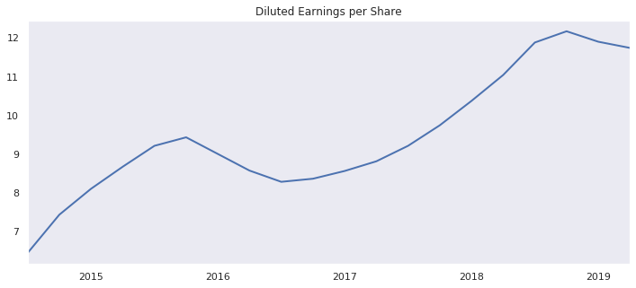

```python
eps.plot(lw=2, figsize=(12, 5), title='Diluted Earnings per Share')
plt.grid(False)
plt.xlabel('')
plt.show()
#plt.savefig('diluted eps', dps=300);
```

# [Quandl](https://www.quandl.com/)

Quandl provides a broad range of data sources, both free and as a subscription, using a Python API. Register and obtain a free API key to make more than `50` calls/day. Quandl data covers multiple asset classes beyond equities and includes FX, fixed income, indexes, futures and options, and commodities. API usage is straightforward, well documented, and flexible, with numerous methods beyond single-series downloads, for example, including bulk downloads or metadata searches. The following call obtains the prices for AAPL for the min and max dates in the AAPL eps series index we created previously.

```python
symbol = 'AAPL.US'

aapl_stock = (web.
              DataReader(symbol, 'quandl', start=eps.index.min(), api_key='Your-API-Key-Here')
              .resample('D')
              .last()
             .loc['2014':eps.index.max()])
aapl_stock.info()
```

```
<class 'pandas.core.frame.DataFrame'>
DatetimeIndex: 1275 entries, 2014-09-30 to 2018-03-27
Freq: D
Data columns (total 12 columns):
Open          877 non-null float64
High          877 non-null float64
Low           877 non-null float64
Close         877 non-null float64
Volume        877 non-null float64
ExDividend    877 non-null float64
SplitRatio    877 non-null float64
AdjOpen       877 non-null float64
AdjHigh       877 non-null float64
AdjLow        877 non-null float64
AdjClose      877 non-null float64
AdjVolume     877 non-null float64
dtypes: float64(12)
memory usage: 129.5 KB
```

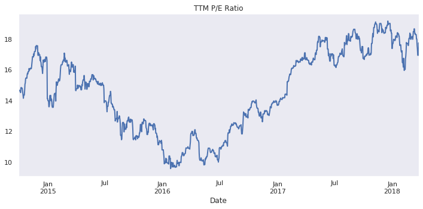

```python
pe = aapl_stock.AdjClose.to_frame('price').join(eps.to_frame('eps'))
pe = pe.fillna(method='ffill').dropna()
pe['P/E Ratio'] = pe.price.div(pe.eps)
pe['P/E Ratio'].plot(lw=2, figsize=(12, 5), title='TTM P/E Ratio')
plt.grid(False);
```

```python
pe.info()
```

```
<class 'pandas.core.frame.DataFrame'>
DatetimeIndex: 1275 entries, 2014-09-30 to 2018-03-27
Freq: D
Data columns (total 3 columns):
price        1275 non-null float64
eps          1275 non-null float64
P/E Ratio    1275 non-null float64
dtypes: float64(3)
memory usage: 39.8 KB
```

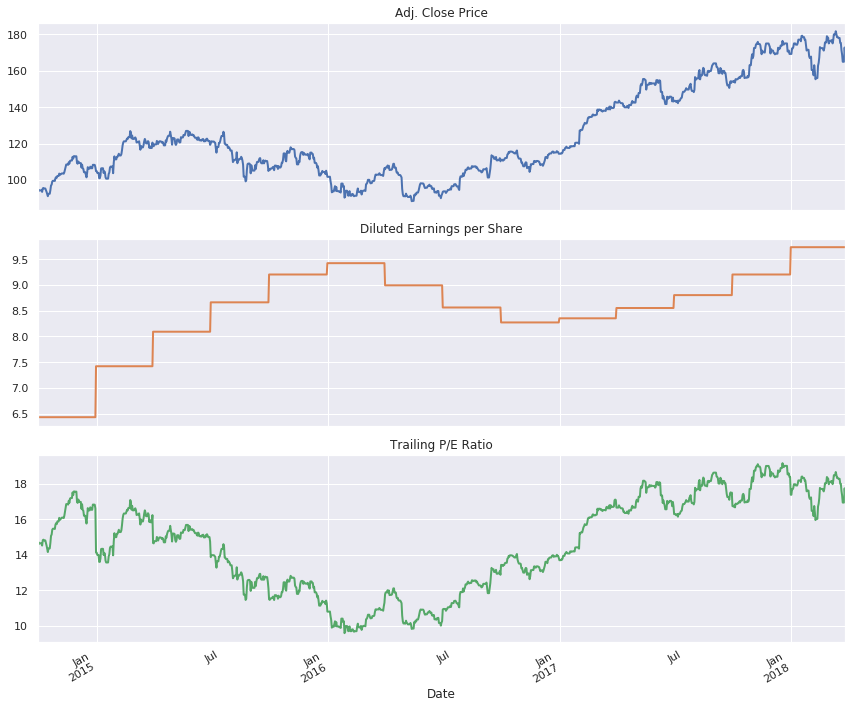

```python
axes = pe.plot(subplots=True, figsize=(12,10), legend=False, lw=2)
axes[0].set_title('Adj. Close Price')
axes[1].set_title('Diluted Earnings per Share')
axes[2].set_title('Trailing P/E Ratio')
plt.tight_layout();
```

## Explore Additional Fields

The field `tag` references values defined in the taxonomy:

```python
aapl_nums.tag.unique()
```

```
array(['DecreaseInUnrecognizedTaxBenefitsIsReasonablyPossible',
       'OtherComprehensiveIncomeLossAvailableForSaleSecuritiesAdjustmentNetOfTax',
       'OtherComprehensiveIncomeLossReclassificationAdjustmentFromAOCIForSaleOfSecuritiesNetOfTax',
       'DeferredTaxAssetsLiabilitiesNet',
       'AntidilutiveSecuritiesExcludedFromComputationOfEarningsPerShareAmount',
       'OtherComprehensiveIncomeLossTaxPortionAttributableToParent1',
       'OtherComprehensiveIncomeUnrealizedGainLossOnDerivativesArisingDuringPeriodNetOfTax',
       'ContractWithCustomerLiabilityCurrent',
       'IncreaseDecreaseInInventories',
       'IncreaseDecreaseInOtherOperatingAssets',
       'ContractWithCustomerLiability',
       'ChangeInUnrealizedGainLossOnHedgedItemInFairValueHedge1',
       'InvestmentIncomeInterestAndDividend',
       'CommonStockSharesAuthorized', 'ComprehensiveIncomeNetOfTax',
       'AssetsNoncurrent', 'Assets',
       'CommonStockDividendsPerShareDeclared',
       'CollateralAlreadyPostedAggregateFairValue',
       'AccruedIncomeTaxesNoncurrent', 'LongTermDebtFairValue',
       'CashAndCashEquivalentsAtCarryingValue', 'Liabilities',
       'AccumulatedOtherComprehensiveIncomeLossNetOfTax',
       'CashCashEquivalentsRestrictedCashAndRestrictedCashEquivalents',
       'PaymentsToAcquireOtherInvestments', 'PaymentsOfDividends',
       'AvailableForSaleDebtSecuritiesAmortizedCostBasis',
       'AvailableForSaleSecuritiesDebtSecurities',
       'DerivativeFairValueOfDerivativeAsset',
       'DerivativeFairValueOfDerivativeLiability',
       'DerivativeFairValueOfDerivativeNet', 'InterestExpense',
       'InterestExpenseDebt',
       'ShareBasedCompensationArrangementByShareBasedPaymentAwardEquityInstrumentsOtherThanOptionsVestedInPeriod',
       'ShareBasedCompensationArrangementByShareBasedPaymentAwardEquityInstrumentsOtherThanOptionsVestedInPeriodWeightedAverageGrantDateFairValue',
       'AllocatedShareBasedCompensationExpense',
       'StandardProductWarrantyAccrual', 'DebtInstrumentFaceAmount',
       'OperatingIncomeLoss', 'NonoperatingIncomeExpense',
       'EarningsPerShareDiluted',
       'CumulativeEffectOfNewAccountingPrincipleInPeriodOfAdoption',
       'ShareBasedCompensation', 'RepaymentsOfLongTermDebt',
       'WeightedAverageNumberDilutedSharesOutstandingAdjustment',
       'PerformanceObligationsinArrangements',
       'DebtSecuritiesAvailableForSaleContinuousUnrealizedLossPosition12MonthsOrLonger',
       'DebtSecuritiesAvailableForSaleContinuousUnrealizedLossPositionLessThan12MonthsAccumulatedLoss',
```

[output cut: 384 more lines]

```
       'ShareBasedCompensationArrangementByShareBasedPaymentAwardOptionsExpectedToVestIntrinsicValueAtPeriodEnd',
       'ShareBasedCompensationArrangementByShareBasedPaymentAwardOptionsExercisableNumber',
       'ShareBasedCompensationArrangementByShareBasedPaymentAwardOptionsGrantsInPeriod',
       'SharebasedCompensationArrangementBySharebasedPaymentAwardOptionsExercisableIntrinsicValue1',
       'ShareBasedCompensationArrangementByShareBasedPaymentAwardStockPurchaseRightsGrantsInPeriodWeightedAverageGrantDateFairValue',
       'ShareBasedCompensationArrangementByShareBasedPaymentAwardOptionsExpectedToVestWeightedAverageExercisePrice',
       'IndefiniteLivedIntangibleAssetsAccumulatedAmortization',
       'IndefiniteLivedIntangibleAssetsGross',
       'ShareBasedCompensationArrangementByShareBasedPaymentAwardOptionsAssumedInPeriod',
       'ResultOfLegalProceedingsAdditionalAmountAwarded',
       'ResultOfLegalProceedingsAwardUpHeld',
       'FederalIncomeTaxesProvidedonForeignPreTaxEarnings',
       'SalesRevenueServicesGross',
       'SharebasedCompensationArrangementbySharebasedPaymentAwardOptionsNumberofSharesofCommonSharesAwardedUponSettlement'],
      dtype=object)
```

We can select values of interest and track their value or use them as inputs to compute fundamental metrics like the Dividend/Share ratio.

### Dividends per Share

```python
fields = ['EarningsPerShareDiluted',
          'PaymentsOfDividendsCommonStock',
          'WeightedAverageNumberOfDilutedSharesOutstanding',
          'OperatingIncomeLoss',
          'NetIncomeLoss',
          'GrossProfit']
```

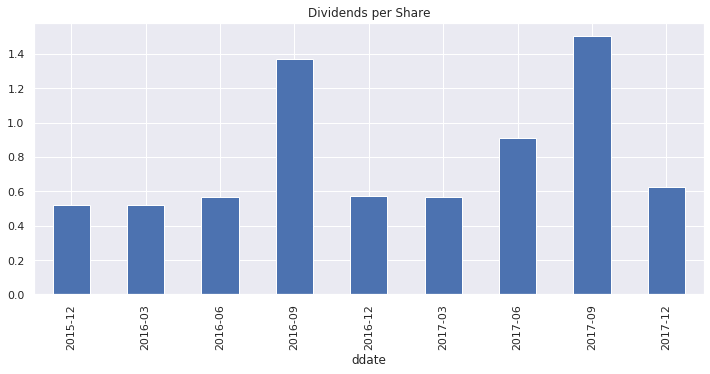

```python
dividends = (aapl_nums
             .loc[aapl_nums.tag == 'PaymentsOfDividendsCommonStock', ['ddate', 'value']]
             .groupby('ddate')
             .mean())
shares = (aapl_nums
          .loc[aapl_nums.tag == 'WeightedAverageNumberOfDilutedSharesOutstanding', ['ddate', 'value']]
          .drop_duplicates()
          .groupby('ddate')
          .mean())
df = dividends.div(shares).dropna()
ax = df.plot.bar(figsize=(12, 5), title='Dividends per Share', legend=False)
ax.xaxis.set_major_formatter(mticker.FixedFormatter(df.index.strftime('%Y-%m')))
```

## Textual Information

```python
txt = pd.read_parquet(data_path / '2016_2' / 'parquet' /  'txt.parquet')
```

You can obtain notes from the financial statesments here:

```python
txt.head()
```

|  | adsh | tag | version | ddate | qtrs | iprx | lang | dcml | durp | datp | dimh | dimn | coreg | escaped | srclen | txtlen | footnote | footlen | context | value |
| --- | --- | --- | --- | --- | --- | --- | --- | --- | --- | --- | --- | --- | --- | --- | --- | --- | --- | --- | --- | --- |
| 0 | 0000014693-16-000160 | AdvertisingCostsPolicyTextBlock | us-gaap/2015 | 20160430 | 4 | 0 | en-US | 32767 | 0.0 | 0.0 | 0x00000000 | 0 | None | 1 | 425 | 112 | None | 0 | FD2016Q4YTD | Advertising costs. We expense the costs of adv... |
| 1 | 0000014693-16-000160 | AmendmentFlag | dei/2014 | 20160430 | 4 | 0 | en-US | 32767 | 0.0 | 0.0 | 0x00000000 | 0 | None | 0 | 5 | 5 | None | 0 | FD2016Q4YTD | false |
| 2 | 0000014693-16-000160 | ComprehensiveIncomeNoteTextBlock | us-gaap/2015 | 20160430 | 4 | 0 | en-US | 32767 | 0.0 | 0.0 | 0x00000000 | 0 | None | 1 | 82857 | 2106 | None | 0 | FD2016Q4YTD | ACCUMULATED OTHER COMPREHENSIVE INCOME The fol... |
| 3 | 0000014693-16-000160 | EntityFilerCategory | dei/2014 | 20160430 | 4 | 0 | en-US | 32767 | 0.0 | 0.0 | 0x00000000 | 0 | None | 0 | 23 | 23 | None | 0 | FD2016Q4YTD | Large Accelerated Filer |
| 4 | 0000014693-16-000160 | ScheduleOfComprehensiveIncomeLossTableTextBlock | us-gaap/2015 | 20160430 | 4 | 0 | en-US | 32767 | 0.0 | 0.0 | 0x00000000 | 0 | None | 1 | 67007 | 1686 | None | 0 | FD2016Q4YTD | The following table presents the components of... |

Obtain data for AAPL by searching for presence of its unique adsh value.

```python
aapl_txt = txt[txt['adsh'].isin(list(aapl_nums.adsh.unique()))]
aapl_txt.head()
```

|  | adsh | tag | version | ddate | qtrs | iprx | lang | dcml | durp | datp | dimh | dimn | coreg | escaped | srclen | txtlen | footnote | footlen | context | value |
| --- | --- | --- | --- | --- | --- | --- | --- | --- | --- | --- | --- | --- | --- | --- | --- | --- | --- | --- | --- | --- |
| 126732 | 0001193125-16-559625 | DocumentType | dei/2014 | 20160331 | 2 | 0 | en-US | 32767 | 0.016439 | 5.0 | 0x00000000 | 0 | None | 0 | 4 | 4 | None | 0 | eol_PE2035----1610-Q0006_STD_182_20160326_0 | 10-Q |
| 126733 | 0001193125-16-559625 | ReconciliationOfOperatingProfitLossFromSegment... | us-gaap/2015 | 20160331 | 2 | 0 | en-US | 32767 | 0.016439 | 5.0 | 0x00000000 | 0 | None | 1 | 11057 | 556 | None | 0 | eol_PE2035----1610-Q0006_STD_182_20160326_0 | A reconciliation of the Companys segment opera... |
| 126734 | 0001193125-16-559625 | ComprehensiveIncomeNoteTextBlock | us-gaap/2015 | 20160331 | 2 | 0 | en-US | 32767 | 0.016439 | 5.0 | 0x00000000 | 0 | None | 1 | 37057 | 2092 | None | 0 | eol_PE2035----1610-Q0006_STD_182_20160326_0 | Note 8 Comprehensive Income Comprehensive inc... |
| 126735 | 0001193125-16-559625 | ScheduleOfIndefiniteLivedIntangibleAssetsTable... | us-gaap/2015 | 20160331 | 2 | 0 | en-US | 32767 | 0.016439 | 5.0 | 0x00000000 | 0 | None | 1 | 13669 | 607 | None | 0 | eol_PE2035----1610-Q0006_STD_182_20160326_0 | The following table summarizes the components ... |
| 126736 | 0001193125-16-559625 | ScheduleOfProductWarrantyLiabilityTableTextBlock | us-gaap/2015 | 20160331 | 2 | 0 | en-US | 32767 | 0.016439 | 5.0 | 0x00000000 | 0 | None | 1 | 11024 | 536 | None | 0 | eol_PE2035----1610-Q0006_STD_182_20160326_0 | The following table shows changes in the Compa... |

Make sure we have the correct company by checking the value of the TradingSymbol tag.

```python
aapl_txt[aapl_txt['tag'] == 'TradingSymbol']['value']
```

```
163651    AAPL
Name: value, dtype: object
```

## Explore Additional Text Data Fields

```python
aapl_txt.tag.unique()
```

```
array(['DocumentType',
       'ReconciliationOfOperatingProfitLossFromSegmentsToConsolidatedTextBlock',
       'ComprehensiveIncomeNoteTextBlock',
       'ScheduleOfIndefiniteLivedIntangibleAssetsTableTextBlock',
       'ScheduleOfProductWarrantyLiabilityTableTextBlock',
       'MaximumLengthOfTimeHedgedInInterestRateCashFlowHedge1',
       'ReclassificationOutOfAccumulatedOtherComprehensiveIncomeTableTextBlock',
       'DividendsDeclaredTableTextBlock',
       'ShareBasedCompensationArrangementByShareBasedPaymentAwardAwardVestingPeriod1',
       'InterestAndOtherIncomeTableTextBlock',
       'DebtInstrumentMaturityYearRangeStart', 'DebtInstrumentTerm',
       'IncomeTaxDisclosureTextBlock',
       'ScheduleOfFiniteLivedIntangibleAssetsTableTextBlock',
       'ScheduleOfEmployeeServiceShareBasedCompensationAllocationOfRecognizedPeriodCostsTextBlock',
       'ScheduleOfCommonStockRepurchasedTableTextBlock',
       'DebtDisclosureTextBlock', 'SegmentReportingDisclosureTextBlock',
       'EmployeeServiceShareBasedCompensationNonvestedAwardsTotalCompensationCostNotYetRecognizedPeriodForRecognition1',
       'SharebasedCompensationArrangementBySharebasedPaymentAwardOptionsOutstandingWeightedAverageRemainingContractualTerm2',
       'StockholdersEquityNoteDisclosureTextBlock',
       'ScheduleOfAccumulatedOtherComprehensiveIncomeLossTableTextBlock',
       'ScheduleOfDerivativeInstrumentsInStatementOfFinancialPositionFairValueTextBlock',
       'EntityCentralIndexKey', 'AcceleratedShareRepurchasesTextBlock',
       'DerivativesPolicyTextBlock',
       'OtherNoncurrentLiabilitiesTableTextBlock',
       'DocumentFiscalYearFocus', 'FiniteLivedIntangibleAssetUsefulLife',
       'IntangibleAssetsDisclosureTextBlock',
       'LesseeLeasingArrangementsOperatingLeasesTermOfContract',
       'EntityFilerCategory', 'DocumentFiscalPeriodFocus',
       'BasisOfPresentationAndSignificantAccountingPoliciesTextBlock',
       'MaximumLengthOfTimeForeignCurrencyCashFlowHedge',
       'NotionalAndCreditRiskAmountsOfOutstandingDerivativePositionsDisclosureTextBlock',
       'PropertyPlantAndEquipmentTextBlock', 'AmendmentFlag',
       'CommitmentsAndContingenciesDisclosureTextBlock',
       'CommercialPaperCashFlowSummaryTableTextBlock',
       'LongTermMarketableSecuritiesMaturitiesTermMaximum',
       'EntityRegistrantName', 'IncomeTaxContingencyPeriodOfOccurrence',
       'TradingSymbol',
       'ScheduleOfEarningsPerShareBasicAndDilutedTableTextBlock',
       'ScheduleOfCashAndCashEquivalentsTableTextBlock',
       'LongtermPurchaseCommitmentPeriod',
       'BasisOfAccountingPolicyPolicyTextBlock',
       'EarningsPerSharePolicyTextBlock',
       'CompensationAndEmployeeBenefitPlansTextBlock',
       'ScheduleOfNonvestedRestrictedStockUnitsActivityTableTextBlock',
       'DocumentPeriodEndDate', 'CurrentFiscalYearEndDate',
       'FinancialInstrumentsDisclosureTextBlock',
       'ScheduleOfDerivativeInstrumentsGainLossInStatementOfFinancialPerformanceTextBlock',
       'ScheduleOfSegmentReportingInformationBySegmentTextBlock',
       'DebtInstrumentMaturityYearRangeEnd',
       'ScheduleOfDebtInstrumentsTextBlock',
       'StockRepurchaseProgramCompletionDate',
       'AdditionalFinancialInformationDisclosureTextBlock',
       'LongTermMarketableSecuritiesMaturitiesTermMinimum',
       'DebtInstrumentMaturityYear',
       'AvailableForSaleSecuritiesTextBlock'], dtype=object)
```

Locate and read the text value for specific tag

```python
tag = aapl_txt[aapl_txt['tag'] == 'StockholdersEquityNoteDisclosureTextBlock']['adsh'].index[0]
tag
```

```
141087
```

```python
aapl_txt.value[tag]
```

```
'Note 7  Shareholders Equity Dividends The Company declared and paid cash dividends per share during the periods presented as follows: Dividends Per Share Amount (in millions) 2016: Second quarter $ 0.52 $ 2,879 First quarter 0.52 2,898 Total cash dividends declared and paid $ 1.04 $ 5,777 2015: Fou…
```